# R Notebook

## Import ggplot2 library

```r
library(ggplot2) #must load the ggplot package first
library(dplyr)
data(diamonds) #loads the diamonds data set since it comes with the ggplot package
```

# 1. Quiz: Price Histograms with Facet and Color

Create a histogram of diamond prices. Facet the histogram by diamond color and use cut to color the histogram bars.

The plot should look something like this. http://i.imgur.com/b5xyrOu.jpg

Note: In the link, a color palette of type ‘qual’ was used to color the histogram using scale_fill_brewer(type = ‘qual’)

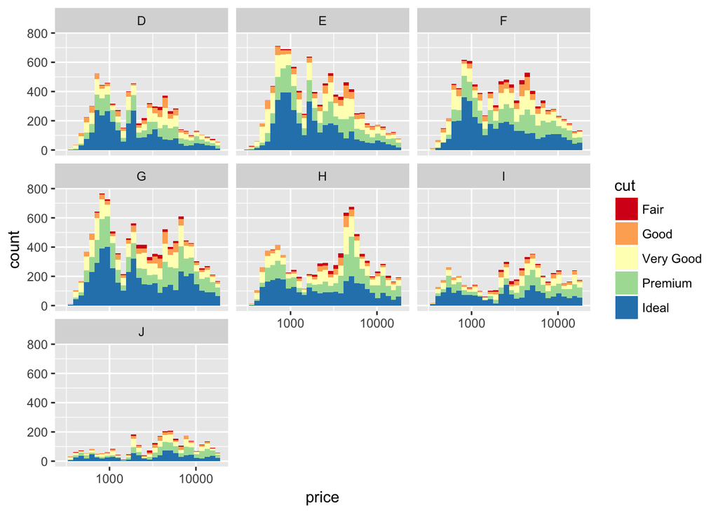

```r
ggplot(aes(x = price), data = diamonds) +
  geom_histogram(aes(fill = cut)) +
  scale_x_log10() +
  facet_wrap(~color) +
  #scale_fill_brewer(type = 'qual')
  scale_fill_brewer(palette="Spectral")
```

# 2. Quize: Price vs. Table Colored by Cut

Create a scatterplot of diamond price vs. table and color the points by the cut of the diamond.

The plot should look something like this. http://i.imgur.com/rQF9jQr.jpg

Note: In the link, a color palette of type ‘qual’ was used to color the scatterplot using scale_color_brewer(type = ‘qual’)

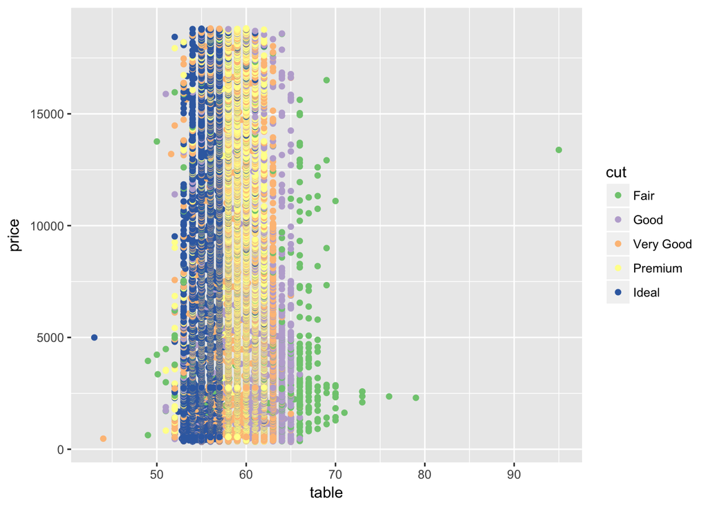

```r
ggplot(aes(x = table, y = price), data = diamonds) +
  geom_point(aes(colour = cut)) +
  #scale_fill_brewer(palette="Spectral")
  scale_color_brewer(type = 'qual')
```

# 3. Quiz: Typical Table Value

What is the typical table range for the majority of diamonds of ideal cut?

```r
subset(diamonds, cut == 'Ideal')$table %>%
  summary()
```

```
##    Min. 1st Qu.  Median    Mean 3rd Qu.    Max.
##   43.00   55.00   56.00   55.95   57.00   63.00
```

What is the typical table range for the majority of diamonds of premium cut?

```r
subset(diamonds, cut == 'Premium')$table %>%
  summary()
```

```
##    Min. 1st Qu.  Median    Mean 3rd Qu.    Max.
##   51.00   58.00   59.00   58.75   60.00   62.00
```

# 4. Quiz: Price vs. Volume and Diamond Clarity

Create a scatterplot of diamond price vs. volume (x * y * z) and color the points by the clarity of diamonds. Use scale on the y-axis to take the log10 of price. You should also omit the top 1% of diamond volumes from the plot.

Note: Volume is a very rough approximation of a diamond’s actual volume.

The plot should look something like this. http://i.imgur.com/excUpea.jpg

Note: In the link, a color palette of type ‘div’ was used to color the scatterplot using scale_color_brewer(type = ‘div’)